# Practical Machine Learning Course Project

hont

April 10, 2016

## Overview

With a large amount of data about personal activity which collected using devices such as *Jawbone Up*, *Nike FuelBand*, and *Fitbit*, most of the people tends to focus on how much of a particular activity they do, rather than quantify how well they do it.

In this project, we are given data taken from the accelerometers on the belt, forearm, arm and dumbell of 6 participants. They were asked to perform barbell lifts correctly and incorrectly in 5 different ways. The training data consists of accelerometer data and a label (‘classe’) indicating the way/quality of the activity the participants were doing. Whereas the testing data consists of accelerometer data without the label. The objective of the project is to predict the labels for the test set observations.

## Data

The training data for this project are available here:

https://d396qusza40orc.cloudfront.net/predmachlearn/pml-training.csv

The test data are available here:

https://d396qusza40orc.cloudfront.net/predmachlearn/pml-testing.csv

### Libraries

```r
library(lattice)
library(ggplot2)
library(caret)
library(randomForest)
library(rpart)
library(rpart.plot)
library(corrplot)
```

## Data Processing

### 1. Getting and loading the data

```r
# reading training set data
training <- read.csv("pml-training.csv", na.strings = c("NA", ""))
# reading testing set data
testing <- read.csv("pml-testing.csv", na.strings = c("NA", ""))
dim(training)
```

```
## [1] 19622   160
```

```r
dim(testing)
```

```
## [1]  20 160
```

The training data contains 19622 observations and 160 variables, while the testing data contains 20 observations and 160 variables. The outcome of the variable that will be predicted in the training set is ‘classe’.

### 2. Cleaning data

```r
#Remove NA
training <- training[, colSums(is.na(training)) == 0]
testing <- testing[, colSums(is.na(testing)) == 0]
```

#### 2.2 Subset the columns and data that required for analysis

The first 7 variables/predictors will be removed because these variables have little predicting influence for the ‘classe’ outcome.

```r
#Subject to exclude first 7 variables
trainCleanData <- training[, -c(1:7)]
testCleanData <- testing[, -c(1:7)]
dim(trainCleanData)
```

```
## [1] 19622    53
```

```r
dim(testCleanData)
```

```
## [1] 20 53
```

After performing removal & subset of data, now the training data contains 19622 observations with 53 variables. The testing data contains 20 observations with 53 variables. The two sets of data having the same variables for the first 52 columns, and ended with ‘classe’ and ‘problem_id’ columns respectively.

## Data Modeling

### Data Spliting for Cross Validation

The cleaned training data will be split into a training data set (70%) and a validation data set (30%). So that validation data set will be used to perform cross validation, i.e: to calculate the out-of-sample errors.

```r
set.seed(1234) # for reproducible
inTrain <- createDataPartition(trainCleanData$classe, p=0.70, list=FALSE)
trainDataSet <- trainCleanData[inTrain, ]
testDataSet <- trainCleanData[-inTrain, ]
```

### Random Forests Prediction Algorithm

The **Random Forests** algorithm is one of the best among classification algorithms as able to classify large amounts of data with accuracy. Hence, **Random Forests** algorithm is chosen in the prediction model, on the ‘trainDataSet’ and use *5-fold cross-validation* when applying the algorithm.

```r
controlRF <- trainControl(method="cv", 5)
modelRF <- train(classe ~ ., data=trainDataSet, method="rf", trControl=controlRF, ntree=250)
modelRF
```

```
## Random Forest
##
## 13737 samples
##    52 predictor
##     5 classes: 'A', 'B', 'C', 'D', 'E'
##
## No pre-processing
## Resampling: Cross-Validated (5 fold)
## Summary of sample sizes: 10990, 10988, 10991, 10990, 10989
## Resampling results across tuning parameters:
##
##   mtry  Accuracy   Kappa      Accuracy SD  Kappa SD
##    2    0.9919925  0.9898699  0.001992891  0.002521750
##   27    0.9924292  0.9904231  0.001897842  0.002400921
##   52    0.9874061  0.9840696  0.003823435  0.004834796
##
## Accuracy was used to select the optimal model using  the largest value.
## The final value used for the model was mtry = 27.
```

### Cross Validation & Predict Outcome

Then, the performance of the model on the validation data set is examined.

```r
predictRF <- predict(modelRF, testDataSet)
confMatRF <- confusionMatrix(testDataSet$classe, predictRF)

accuracyRF <- confMatRF$overall[1]
accuracyRF
```

```
##  Accuracy
## 0.9942226
```

```r
OutSampleErr <- 1 - as.numeric(accuracyRF)
OutSampleErr
```

```
## [1] 0.0057774
```

From result above, the estimated accuracy of the model is 99.42% and the estimated out-of-sample error is 0.58%. This could probably concluded that many predictors are highly correlated.

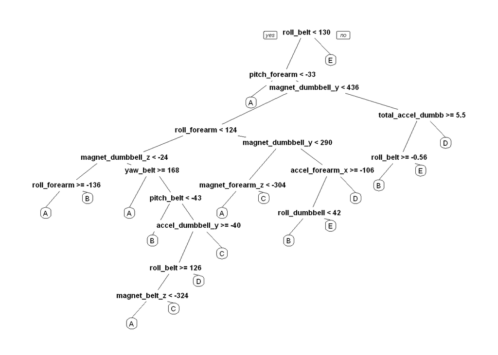

```r
#Decision Visualization
treeModel <- rpart(classe ~ ., data=trainDataSet, method="class")
prp(treeModel)
```

### Prediction for the Test Data

```r
#Define write files function
pml_write_files = function(x) {
  n = length(x)
  for (i in 1:n) {
    filename = paste0("problem_id_", i, ".txt")
    write.table(x[i], file=filename, quote=FALSE,row.names=FALSE, col.names=FALSE)
  }
}

result <- predict(modelRF, testing[, -length(names(testing))])
result
```

```
##  [1] B A B A A E D B A A B C B A E E A B B B
## Levels: A B C D E
```

```r
#Write the prediction result to files
pml_write_files(result)
```

## Conclusion

**Random Forests** model that was chosen in this course project given high accuracy in prediction, thus this model was applied to the 20 test cases to predict the ‘classe’ variable.